# Poisson GLM

March 29, 2017

## Review: Poisson distribution

Common distribution to model **count data**: the number of individuals, arrivals, events, etc., in a given time/space/unit of effort if each event is independent of all the others.

#### Ex1. You survey a location for the number of mantas you see in 2 hours. You think each manta sighting is independent. If the true mean density (# of mantas seen per 2 hours) is 8, plot the probability density function of seeing between 0 and 20 mantas.

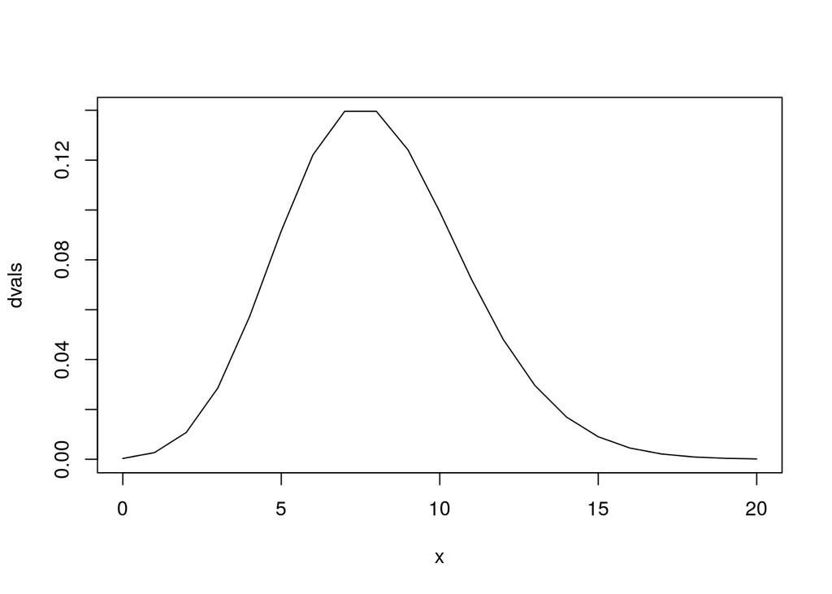

```r
x <- 0:20
dvals <- dpois(x,lambda=8)
plot(x,dvals,type='l')
```

You see 5 mantas in your 2-hour survey, less than the mean (= 8). Unlucky!

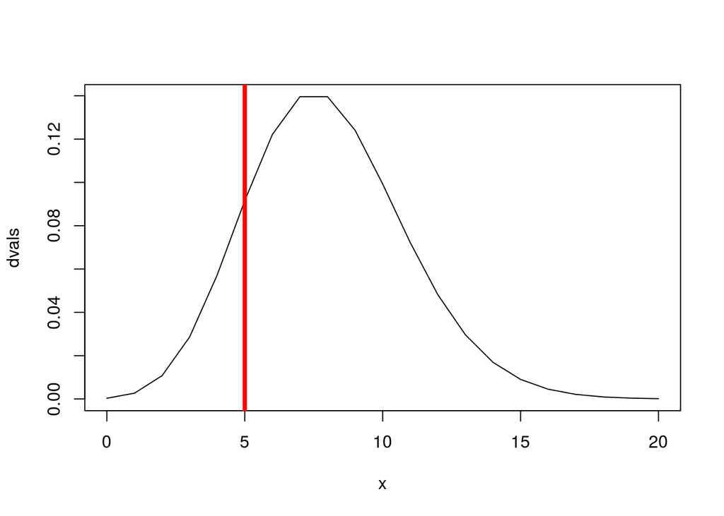

What is the probability any random 2-hour survey would see **more** than you did?

```r
ppois(5,lambda=8,lower.tail=FALSE)
```

```
## [1] 0.8087639
```

## Poisson GLM

If your response variable is count data, then a Poisson GLM is probably more appropriate than ANOVA or simple linear regression **because they assume your data is normally distributed**. In Ex1, we could use `dpois` and `ppois` because we knew the true density. We will never know the true density, and we will want to *estimate it using our count data*.

#### Poisson GLM estimates density from count data (surveys)

#### Ex2. Manta surveys by site.

Looks like ANOVA (3 sites). Let’s plot our data and then test ANOVA assumptions.

```r
library(dplyr)
library(multcomp)
# read in data
setwd("/home/brian/Documents/Workshops/Mexico fisheries/StatsClass")
dat <- read.csv("poissonGLM.csv", header=TRUE)
# look at data
head(dat)
names(dat)
dim(dat)
summary(dat)
```

[output not shown]

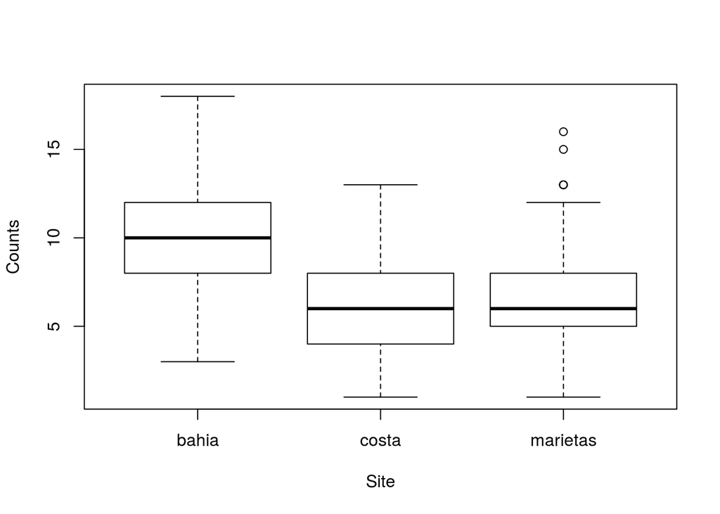

```r
# boxplot of counts by site
boxplot(counts ~ site, data=dat,
        xlab="Site",
        ylab="Counts")
```

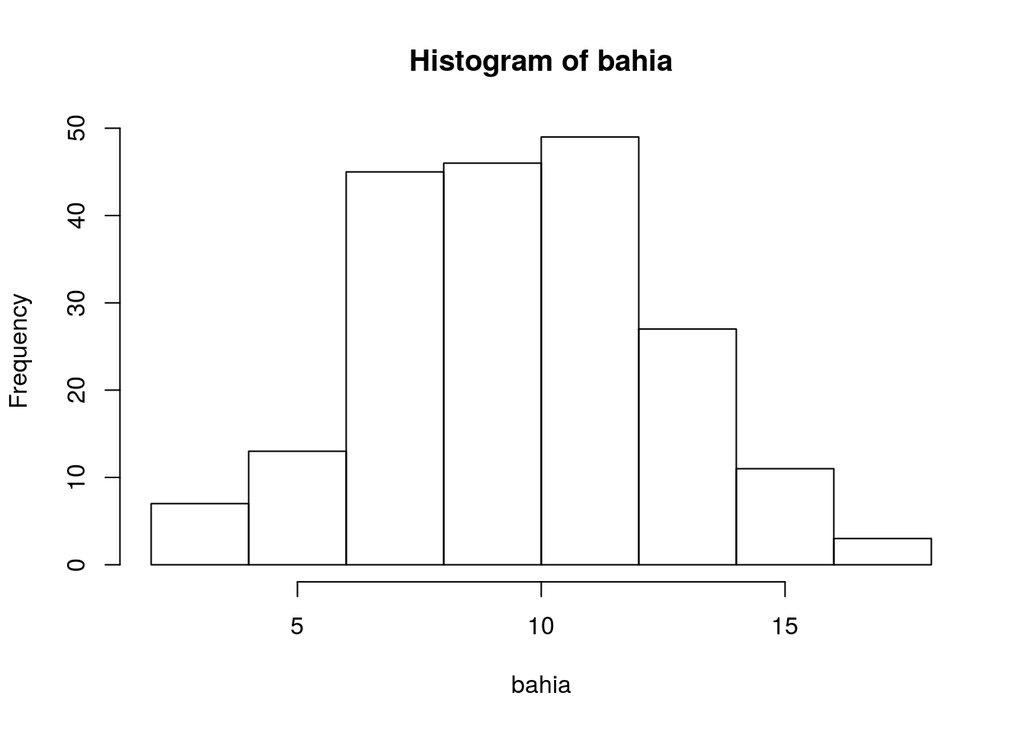

```r
# plot each site's distribution of counts
bahia <- filter(dat, site=="bahia")$counts
costa <- filter(dat, site=="costa")$counts
marietas <- filter(dat, site=="marietas")$counts

hist(bahia)
```

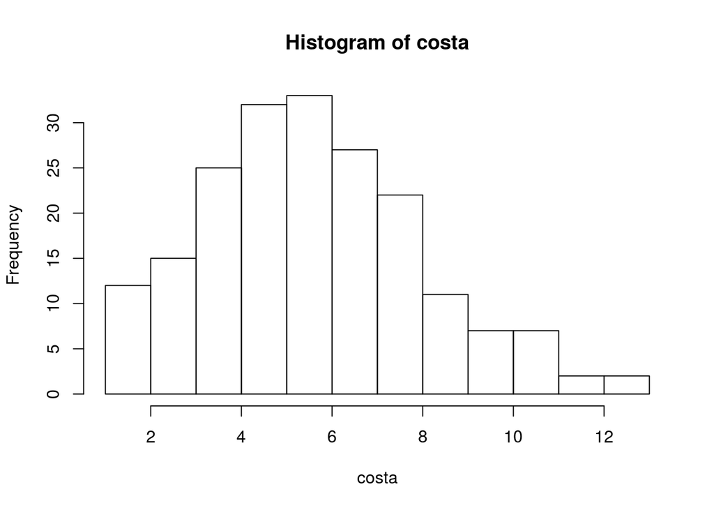

```r
hist(costa)
```

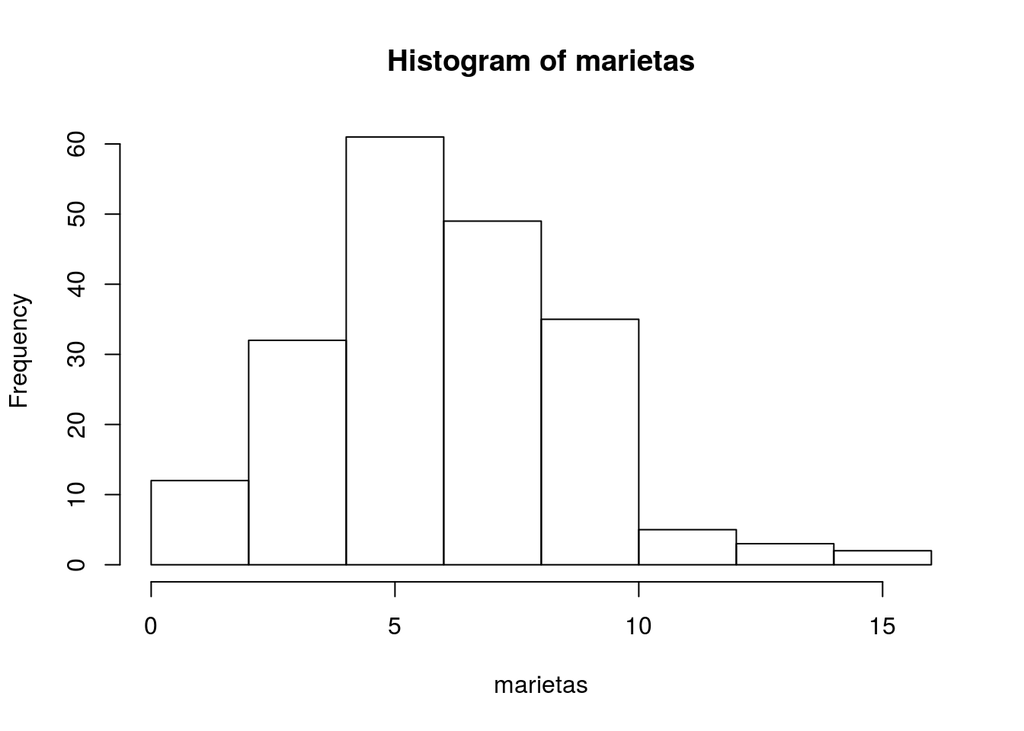

```r
hist(marietas)
```

ANOVA assumes each site is normally distributed. Look at QQ plots:

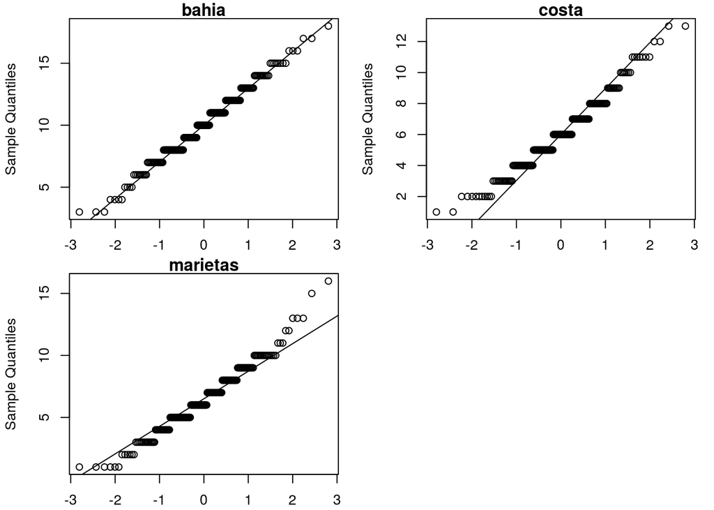

```r
par(mfrow = c(2,2), mar=c(2, 4, 1, 1) + 0.1)
qqnorm(bahia, main="bahia")
qqline(bahia)
qqnorm(costa, main="costa")
qqline(costa)
qqnorm(marietas, main="marietas")
qqline(marietas)
```

2 problems with histograms / QQ plots:

- discrete data (“steps”)
- “bahia” looks ok but “marietas” and “costa” skewed right

#### Fit a Poisson GLM

```r
pois.mod <- glm(counts ~ site, data=dat, family=poisson)
summary(pois.mod)
```

```
##
## Call:
## glm(formula = counts ~ site, family = poisson, data = dat)
##
## Deviance Residuals:
##      Min        1Q    Median        3Q       Max
## -2.68666  -0.67672  -0.03335   0.59028   3.14507
##
## Coefficients:
##              Estimate Std. Error z value Pr(>|z|)
## (Intercept)   2.30953    0.02223  103.90   <2e-16 ***
## sitecosta    -0.50418    0.03657  -13.79   <2e-16 ***
## sitemarietas -0.44121    0.03564  -12.38   <2e-16 ***
## ---
## Signif. codes:  0 '***' 0.001 '**' 0.01 '*' 0.05 '.' 0.1 ' ' 1
##
## (Dispersion parameter for poisson family taken to be 1)
##
##     Null deviance: 851.73  on 594  degrees of freedom
## Residual deviance: 607.37  on 592  degrees of freedom
## AIC: 2862.5
##
## Number of Fisher Scoring iterations: 4
```

#### How do we interpret this?

The GLM takes `bahia` as the mean, and has estimated deviations from `bahia` as the effects of `costa` and `marietas`.

`sitecosta` has `Estimate` = `-0.50418` and `Pr(>|z|)` `<2e-16 ***`: The density of mantas on the costa is **significantly lower** than in bahia.

`sitemarietas` has `Estimate` = `-0.44121` and `Pr(>|z|)` `<2e-16 ***`: The density of mantas at the marietas is **significantly lower** than in bahia.

#### What if we want to test if there is a difference between Costa and Marietas?

We can do a Tukey test on the GLM output just like we did with ANOVA output. Use the same `glht` function from the `multcomp` package:

```r
pois.tukey <- glht(pois.mod, mcp(site="Tukey"))
summary(pois.tukey)
```

```
##
##   Simultaneous Tests for General Linear Hypotheses
##
## Multiple Comparisons of Means: Tukey Contrasts
##
##
## Fit: glm(formula = counts ~ site, family = poisson, data = dat)
##
## Linear Hypotheses:
##                       Estimate Std. Error z value Pr(>|z|)
## costa - bahia == 0    -0.50418    0.03657 -13.787   <1e-04 ***
## marietas - bahia == 0 -0.44121    0.03564 -12.381   <1e-04 ***
## marietas - costa == 0  0.06298    0.04024   1.565     0.26
## ---
## Signif. codes:  0 '***' 0.001 '**' 0.01 '*' 0.05 '.' 0.1 ' ' 1
## (Adjusted p values reported -- single-step method)
```

So our data do NOT show a difference between Costa and Marietas, but we do show Bahia has higher density of mantas than both Costa and Marietas.

#### Calculate mean density for each site

Do this by using the `predict` function with `type="response"`:

```r
newdata <- data.frame(site=c("bahia","costa","marietas"))
predict(pois.mod, newdata, type="response")
```

```
##         1         2         3
## 10.069652  6.082051  6.477387
```

#### Get 95% CI for density estimates by site

```r
pred <- predict(pois.mod, newdata, type="response", se.fit=TRUE)
lwr <- pred$fit - 1.96*pred$se.fit
upr <- pred$fit + 1.96*pred$se.fit
```

So our estimates of mean density and 95% CI are:

- Bahia: 10.1 (9.6 – 10.5)
- Costa: 6.1 (5.7 – 6.4)
- Marietas: 6.5 (6.1 – 6.8)

#### The Poisson GLM fits better than ANOVA/normal (lower AIC)

Also see that the Normal GLM is identical to an ANOVA in this case.

```r
aov.mod <- aov(counts ~ site, data=dat)
norm.mod <- glm(counts ~ site, data=dat, family=gaussian)
AIC(pois.mod, aov.mod, norm.mod)
```

```
##          df      AIC
## pois.mod  3 2862.524
## aov.mod   4 2877.657
## norm.mod  4 2877.657
```